# Hypothesis testing

POLI 210 — Seminar 11

Brad LeVeck

November 18, 2026

## From an estimate to a question

A confidence interval describes uncertainty about a population parameter.

A hypothesis test starts with a particular claim:

> If that claim were true, how unusual would our result be?

Today: **null models → tests → two-sample comparisons → power → resampling.**

## Could someone really taste the difference?

Prepare eight cups: four milk-first and four tea-first.

- Present them in a random order.
- Ask the taster to identify exactly four as milk-first.
- Suppose all four are correct.

If the taster were guessing, how often would that happen?

There are $\binom{8}{4}=70$ possible selections, all equally likely under random guessing.

Fisher’s tea-tasting example, following Blackwell’s hypothesis-testing slides.

## A null distribution we can count

Let $K$ count the actual milk-first cups among the four selected.

$$P_0(K=k)=\frac{\binom{4}{k}\binom{4}{4-k}}{\binom{8}{4}}.$$

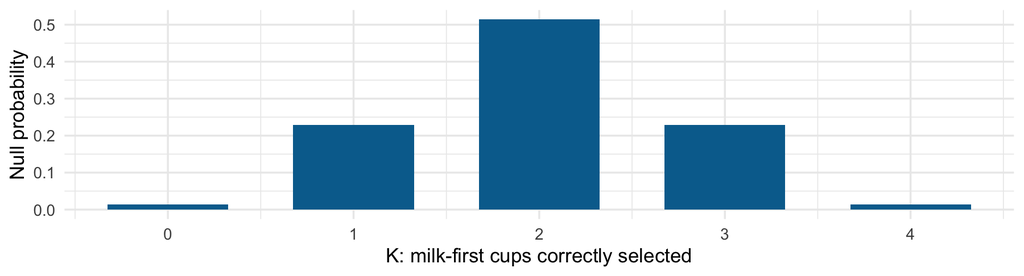

Perfect performance: $P_0(K\geq4)=1/70\approx0.014$.

## Name the claim and the comparison

For a population mean, one possible test is

$$H_0:\mu=50 \qquad\text{versus}\qquad H_A:\mu\ne50.$$

- The **null hypothesis** supplies the claim we evaluate.
- The **alternative** specifies which departures count as evidence.
- A **test statistic** summarizes the departure in our data.
- Its **null distribution** describes repeated results if $H_0$ holds.

The hypotheses concern the population, not the already observed sample mean.

## Standardize the distance from the null

For a mean, a familiar statistic is

$$T=\frac{\overline X-\mu_0}{S/\sqrt n}.$$

It measures the distance from $\mu_0$ in **estimated standard errors**.

For IID observations with finite, positive variance, the studentized CLT gives

$$T\ \overset{H_0}{\approx}\ N(0,1)\qquad\text{for sufficiently large }n.$$

Large positive **or** negative values count against a two-sided null.

## Set a rejection rule before seeing the result

At level $\alpha=.05$, a two-sided Normal-reference test rejects when

$$|T|>z_{0.975}\approx1.96.$$

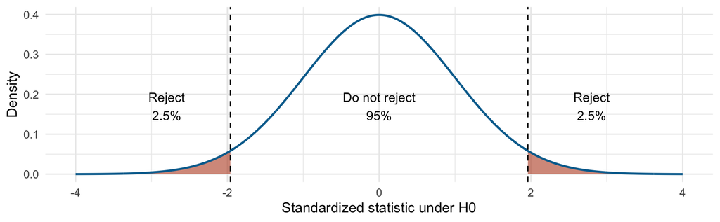

The rejection region has probability 0.05 **under the null approximation**.

## Two ways a decision can be wrong

| Decision | $H_0$ is true | $H_0$ is false |
| --- | --- | --- |
| Reject $H_0$ | Type I error | Detect a departure |
| Do not reject $H_0$ | Correct non-rejection | Type II error |

- **Level $\alpha$:** an upper bound on the Type I error probability for a valid test.
- **Power:** rejection probability under a specified alternative.
- “Do not reject” does not establish that $H_0$ is true.

The costs of the two errors depend on the question; 0.05 is a convention.

## The p-value measures a null tail probability

For a two-sided test based on $|T|$,

$$p=P_0\bigl(|T|\geq|t_{\mathrm{obs}}|\bigr).$$

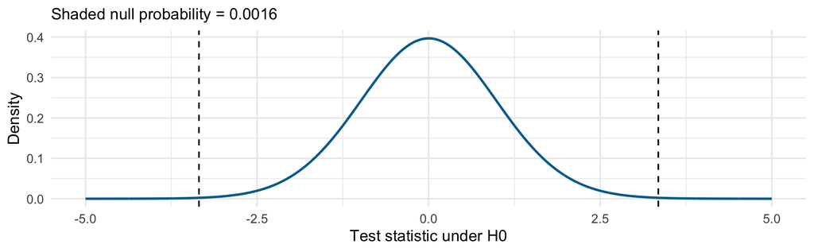

This plot uses the demo’s one-sample t test. Both tails count.

## Keep the conditioning straight

A p-value asks about **possible results under the null model**.

It is not $P(H_0\mid\text{data})$, and it does not measure effect size.

- A tiny effect can give a small p-value in a precise study.
- A consequential effect can be missed in a noisy study.
- Report the estimate and uncertainty alongside the test.

For a prespecified test, reject at level $\alpha$ when $p\leq\alpha$.

## A one-sided question changes the tail

If the prespecified question is whether a mean is **higher** than 50:

$$H_0:\mu\leq50,\qquad H_A:\mu>50.$$

Use the upper tail, calibrated at the boundary $\mu=50$.

```r
t.test(score, mu = 50, alternative = "greater")
```

Choose the direction before examining the data. Switching tails after seeing the result changes the test’s error rate.

## Where the t reference fits

The same statistic can use different justifications:

| Justification | Null reference |
| --- | --- |
| Studentized CLT, sufficiently large IID sample | Approximately $N(0,1)$ |
| IID Normal observations | Exactly $t_{n-1}$ for a one-sample mean |

R’s `t.test()` uses the t reference. Its cutoffs approach the Normal cutoffs as $n$ grows.

A t cutoff does not repair dependence, severe small-sample skewness, or a biased sample.

## The test and interval answer related questions

```r
fit <- t.test(score, mu = 50)
fit$statistic
fit$p.value
fit$conf.int
```

For the demo’s simulated attitude scores:

- Mean = **55.33**; SE = **1.59**.
- $t=$ **3.35**; two-sided $p=$ **0.0016**.
- 95% CI: **[52.13, 58.53]**.

A matching 95% interval excludes the null value exactly when its two-sided test rejects at 5%.

## Return to the turnout experiment

| Mailing | Turnout |
| --- | --- |
| Neighbors | 37.8% |
| Civic duty | 31.5% |

The difference is about **6.3 percentage points**. How much could chance assignment explain?

**Design matters:** treatment was assigned to households within geographic blocks. Individuals in one household are not independent experimental units.

Gerber, Green, and Larimer (2008), Table 2 and experimental design. Rounded summaries; we return to household assignment in the resampling example.

## Two independent samples

Let $\Delta=\mu_Y-\mu_X$, estimated by $\widehat D=\overline Y-\overline X$.

For independent samples,

$$\widehat{\mathrm{SE}}(\widehat D)
=\sqrt{\frac{S_Y^2}{n_Y}+\frac{S_X^2}{n_X}},\qquad
T=\frac{\widehat D-\Delta_0}{\widehat{\mathrm{SE}}(\widehat D)}.$$

Both samples contribute uncertainty. Equal sample sizes or variances are not required.

**Welch’s test** uses this SE and an approximate t reference.

## Compare independent groups in R

```r
# y and x are independent samples of attitude scores.
# The contrast is Y minus X.
t.test(y, x, mu = 0)
```

In the synthetic demo:

- Difference = **5.46** score points.
- SE = **3.2**; $p=$ **0.092**.

This is Welch’s test by default. Independence still matters; a difference between observational groups need not be causal.

## Sometimes the observations come in pairs

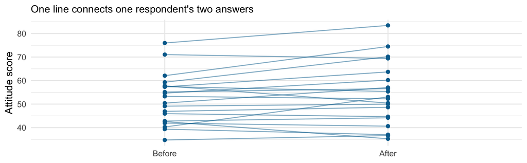

The same person answers twice. Treat each person’s **change** as one observation.

## A paired test is a one-sample test of changes

Let $D_i=\text{after}_i-\text{before}_i$. Test $H_0:E[D_i]=0$.

$$\widehat{\mathrm{SE}}(\overline D)=\frac{S_D}{\sqrt n},
\qquad n=\text{number of independent pairs}.$$

```r
t.test(after, before, paired = TRUE)
t.test(after - before, mu = 0)  # Same test.
```

$$\operatorname{Var}(D_i)=\operatorname{Var}(\text{after}_i)
+\operatorname{Var}(\text{before}_i)-2\operatorname{Cov}(\text{after}_i,\text{before}_i).$$

Positive covariance can make paired comparisons more precise.

## Pause: what makes an observation independent?

- Two separately sampled groups: two-sample SE.
- Two answers from the same person: analyze paired differences.
- Two voters in the same household: preserve the household structure.

The number of rows is not necessarily the number of independent units.

**Break**

## Power asks about repeated studies

For a specified true difference $\delta$,

$$\operatorname{Power}(\delta)=P_\delta(\text{reject }H_0).$$

At a nonzero alternative, power is $1-P_\delta(\text{Type II error})$.

Choose a meaningful effect, a plausible population model, a design, and a test. Then ask how frequently that procedure would detect the effect.

At the null value, the rejection probability is the Type I error rate.

## Keep the cutoffs fixed; change the truth

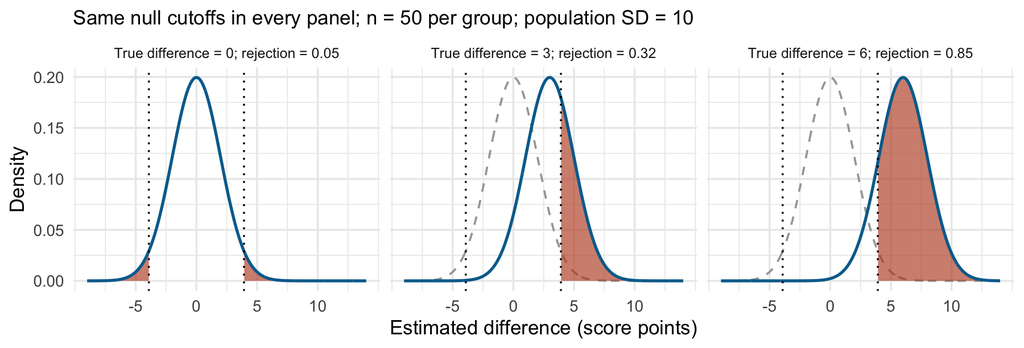

The shaded area is rejection probability under each possible truth.

These are **Normal planning approximations**, using the population SE. The gray dashed curve is the null distribution.

## Simulate the whole testing procedure

```r
reject_once <- function(n_group, delta) {
  x_new <- rnorm(n_group, mean = 50, sd = 10)
  y_new <- rnorm(n_group, mean = 50 + delta, sd = 10)
  t.test(y_new, x_new)$p.value < .05
}
mean(replicate(4000, reject_once(n_group = 60, delta = 3)))
```

One repetition generates a **fresh study**, then runs its test.

- `delta = 0`: estimate the Type I error rate.
- `delta = 3`: estimate power to detect a three-point difference.

## More information can detect smaller effects

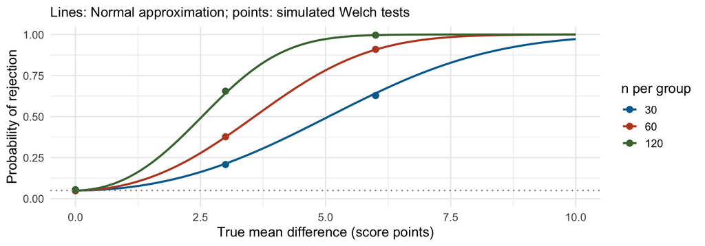

More subjects per group increase power. More simulation repetitions only make our estimate of power more precise.

## Plan around an effect that matters

```r
plan <- power.t.test(
  delta = 3, sd = 10, power = .80,
  sig.level = .05, type = "two.sample",
  alternative = "two.sided", strict = TRUE
)
ceiling(plan$n)  # Number IN EACH GROUP.
```

This calculation gives **176 per group**, under a balanced, common-SD Normal model for a pooled t test.

Simulation accommodates other designs and tests. Household assignment requires a household-aware power calculation.

## A non-rejection can be uninformative

With low power, even an important effect will often produce $p>.05$.

- Inspect the interval: which effect sizes are still compatible with the data?
- A smaller p-value does not necessarily imply a larger effect.
- Do not infer a group difference because one group is “significant” and another is not. **Test the difference itself.**

Statistical detection and substantive importance are different questions.

## Bootstrap: use the empirical distribution

We have one sample and an estimator. We want its sampling uncertainty.

1. Give each observed unit equal probability in a stand-in population.
2. Draw a sample of the original size **with replacement**.
3. Recalculate the statistic.
4. Repeat; use the spread of those estimates to approximate its SE.

The sample can contain repeated observations and omit others.

This is the resampling idea behind the bootstrap intervals supplied in B4.

## A bootstrap SE in a few lines

```r
boot_mean <- replicate(4000, {
  score_star <- sample(score, length(score), replace = TRUE)
  mean(score_star)
})
sd(boot_mean)                     # Bootstrap SE.
quantile(boot_mean, c(.025, .975)) # Approximate interval.
```

For these simulated scores: bootstrap SE = **1.57**; formula SE = **1.59**.

Bootstrap intervals are approximate; resampling does not guarantee coverage.

## This distribution is centered at the estimate

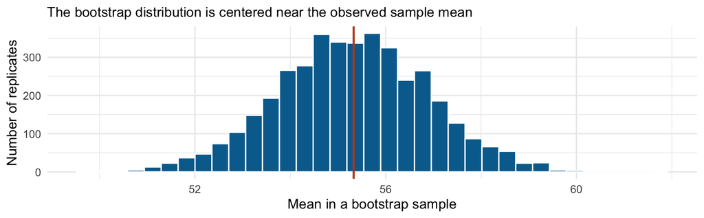

The line is the observed mean. This is **not yet a null distribution** for testing $\mu=50$.

## Keep dependent observations together

A simplified turnout experiment:

- 60 independent households, each with two voters.
- Randomly assign 30 households to treatment and 30 to control.
- Voters within a household have related turnout outcomes.

For a bootstrap, resample **whole households within each arm**.

Synthetic teaching example. Gerber–Green–Larimer used household assignment within geographic blocks and multiple arms; this illustration simplifies their design.

## Summarize households, then resample households

```r
hh <- voters |>
  group_by(household, treated) |>
  summarise(turnout = mean(voted), .groups = "drop")

h_treated <- hh$turnout[hh$treated == 1]
h_control <- hh$turnout[hh$treated == 0]
boot_household <- replicate(4000, {
  mean(sample(h_treated, length(h_treated), replace = TRUE)) -
    mean(sample(h_control, length(h_control), replace = TRUE))
})
```

Equal household sizes make this equivalent to resampling each household with all its voters for our difference in means.

## The resampling unit changes the uncertainty

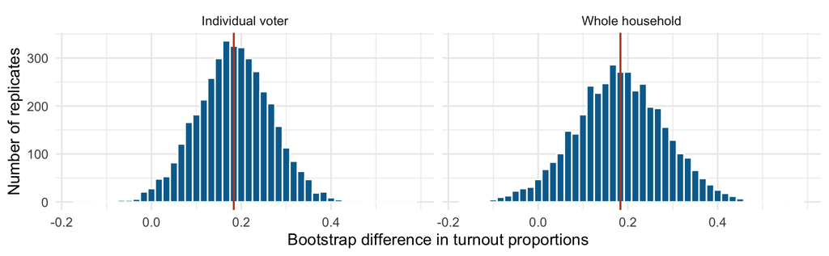

SE from individual resampling: **0.082**. SE from household resampling: **0.1**.

Resampling voters separately breaks their positive association and understates uncertainty here.

## For a test, build a distribution under the null

For our randomized experiment, consider the **sharp null**:

$$H_0:Y_i(1)=Y_i(0)\quad\text{for every voter }i.$$

Under this null, each voter’s observed outcome would stay the same under any allowed assignment.

Keep outcomes fixed. Reassign **household** treatment labels according to the original design, and recalculate the difference.

This is stronger than a null of zero average effect.

## Reassign labels, respecting the experiment

```r
observed <- mean(h_treated) - mean(h_control)
null_difference <- replicate(4000, {
  d_star <- sample(hh$treated, replace = FALSE)
  mean(hh$turnout[d_star == 1]) - mean(hh$turnout[d_star == 0])
})
```

Every household appears once; exactly 30 receive each label.

For a blocked experiment, reassign **within blocks**, preserving each block’s arm counts. Assume no interference between households.

## Compare the observed result with that null

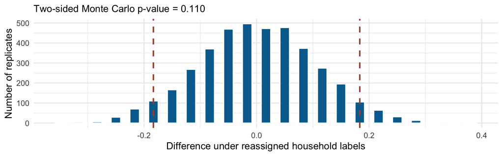

Count differences at least as large in absolute value, including ties:

$$p_{\mathrm{MC}}=\frac{1+\#\{|\widehat D^*|\geq|\widehat D_{\mathrm{obs}}|\}}{B+1}.$$

## Similar code, different repeated experiments

| Method | What changes? | Main question |
| --- | --- | --- |
| Power simulation | New data under a specified truth | How often would this test reject? |
| Bootstrap | Units sampled with replacement | How variable is this estimator? |
| Randomization test | Assignments allowed by the design | How unusual is this result under the sharp null? |

A label permutation is not an exact equal-means test for arbitrary observational groups. It needs an appropriate exchangeability or randomization justification.

## When resampling is especially useful

- **Less familiar statistics:** approximate uncertainty for a median or ratio.
- **Dependent observations:** resample pairs or clusters together.
- **Known assignment designs:** simulate the null using the actual randomization.

Choose a repetition that preserves the source of randomness and dependence.

More resamples cannot fix confounding, selection bias, or too few independent units.

## Questions to ask before running a test

1. What parameter or causal claim is being tested?
2. What would count as evidence against it?
3. Which units are independent, or how was treatment assigned?
4. What justifies the reference distribution?
5. What do the estimate, interval, p-value, and power each tell us?

## Reading and references

- *Probability, Statistics, and Data*, Chapter 8: §§8.3–8.4 and 8.6–8.8; review §§8.1–8.2 and 8.5 as needed. probstatsdata.com/HTCI.html
- Matthew Blackwell, *Gov 2000: Hypothesis Testing* (2016). Tea example and testing/power sequence adapted with permission; graphics redrawn for this seminar.
- Gerber, Green, and Larimer (2008). “Social Pressure and Voter Turnout: Evidence from a Large-Scale Field Experiment.” *APSR* 102(1):33–48. [doi:10.1017/S000305540808009X](https://doi.org/10.1017/S000305540808009X)
- R documentation for [`t.test`](https://stat.ethz.ch/R-manual/R-devel/library/stats/html/t.test.html) and [`power.t.test`](https://stat.ethz.ch/R-manual/R-devel/library/stats/html/power.t.test.html).